# EDA Project

08/08/2024

```r
# Load necessary libraries
library(readxl)
library(dplyr)
```

```r
library(ggplot2)
library(DataExplorer)
library(lattice)
library(caret)
library(randomForest)
library(tidyr)
```

```r
# Load the dataset
dataset <- read_excel("C:/Users/cheic/OneDrive/Desktop/dataset.xlsx")
```

Conduct EDA (Exploratory Data Analysis) to gain an understanding of the Data

```r
# Display the first few rows of the dataset
head(dataset)
```

```
## # A tibble: 6 × 231
##   PATIENT_VISIT_IDENTIFIER AGE_ABOVE65 AGE_PERCENTIL GENDER `DISEASE GROUPING 1`
##                      <dbl>       <dbl> <chr>          <dbl>                <dbl>
## 1                        0           1 60th               0                    0
## 2                        0           1 60th               0                    0
## 3                        0           1 60th               0                    0
## 4                        0           1 60th               0                    0
## 5                        0           1 60th               0                    0
## 6                        1           1 90th               1                    0
## # ℹ 226 more variables: `DISEASE GROUPING 2` <dbl>, `DISEASE GROUPING 3` <dbl>,
## #   `DISEASE GROUPING 4` <dbl>, `DISEASE GROUPING 5` <dbl>,
## #   `DISEASE GROUPING 6` <dbl>, HTN <dbl>, IMMUNOCOMPROMISED <dbl>,
## #   OTHER <dbl>, ALBUMIN_MEDIAN <dbl>, ALBUMIN_MEAN <dbl>, ALBUMIN_MIN <dbl>,
## #   ALBUMIN_MAX <dbl>, ALBUMIN_DIFF <dbl>, BE_ARTERIAL_MEDIAN <dbl>,
## #   BE_ARTERIAL_MEAN <dbl>, BE_ARTERIAL_MIN <dbl>, BE_ARTERIAL_MAX <dbl>,
## #   BE_ARTERIAL_DIFF <dbl>, BE_VENOUS_MEDIAN <dbl>, BE_VENOUS_MEAN <dbl>, …
```

[output not shown]

[output not shown]

[output not shown]

[output not shown]

[output not shown]

[figure not shown]

```r
# Check for missing values
missing_values <- sapply(dataset, function(x) sum(is.na(x)))

# Visualize missing values
plot_missing(dataset)

# Generate a report for the dataset
create_report(dataset)
```

Preprocess the Data to prepare it for the ML Model

```
##
##    0    1
## 1410  515
```

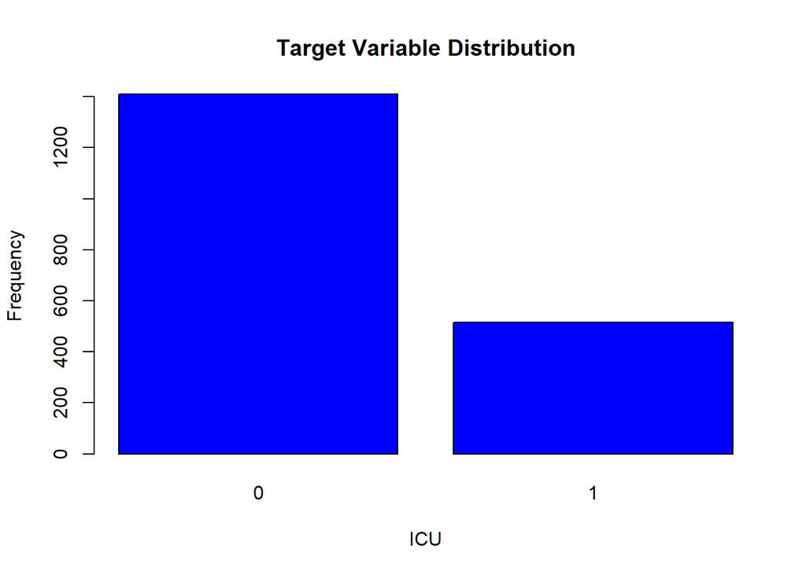

```r
# Check the balance of the target variable (assuming it's named 'ICU')
if("ICU" %in% colnames(dataset)) {
  target_balance <- table(dataset$ICU)
  print(target_balance)
  barplot(target_balance, main = "Target Variable Distribution", xlab = "ICU", ylab = "Frequency", col = "blue")
} else {
  cat("Target variable 'ICU' not found in the dataset.")
}
```

```r
# Preprocess the data

# Handle missing values
# Impute missing values (using median for numeric and mode for categorical)
for (col in colnames(dataset)) {
  if (is.numeric(dataset[[col]])) {
    dataset[[col]][is.na(dataset[[col]])] <- median(dataset[[col]], na.rm = TRUE)
  } else {
    dataset[[col]][is.na(dataset[[col]])] <- as.character(names(sort(table(dataset[[col]]), decreasing = TRUE))[1])
  }
}

# Encode categorical variables
dataset <- dataset %>%
  mutate_if(is.character, as.factor)

# Remove the 'PATIENT_VISIT_IDENTIFIER' column as it is not useful for prediction
dataset <- dataset %>% select(-PATIENT_VISIT_IDENTIFIER)

# Convert ICU to factor
dataset$ICU <- as.factor(dataset$ICU)

# Split the dataset into training and testing sets
set.seed(123)
trainIndex <- createDataPartition(dataset$ICU, p = 0.8, list = FALSE, times = 1)
trainData <- dataset[trainIndex, ]
testData <- dataset[-trainIndex, ]

# Ensure both training and testing sets have the same factor levels for ICU
trainData$ICU <- factor(trainData$ICU, levels = levels(dataset$ICU))
testData$ICU <- factor(testData$ICU, levels = levels(dataset$ICU))

# Feature Selection using Recursive Feature Elimination (RFE)
control <- rfeControl(functions = rfFuncs, method = "cv", number = 5)
results <- rfe(trainData[, -ncol(trainData)], trainData$ICU, sizes = c(1:10), rfeControl = control)
selected_features <- predictors(results)

# Use only selected features for training
trainData_selected <- trainData[, c(selected_features, "ICU")]
testData_selected <- testData[, c(selected_features, "ICU")]
```

Develop a few candidate ML models and pick the most promising one.

```r
# Hyperparameter tuning using grid search

# Grid for Random Forest
rf_grid <- expand.grid(mtry = c(1:10))

# Model 1: Random Forest with Hyperparameter Tuning
model_rf <- train(ICU ~ ., data = trainData_selected, method = "rf", tuneGrid = rf_grid, trControl = trainControl(method = "cv", number = 5))
predictions_rf <- predict(model_rf, newdata = testData_selected)

# Ensure predictions and reference are factors with the same levels
predictions_rf <- factor(predictions_rf, levels = levels(testData_selected$ICU))
confusionMatrix(predictions_rf, testData_selected$ICU)
```

```
## Confusion Matrix and Statistics
##
##           Reference
## Prediction   0   1
##          0 271  43
##          1  11  60
##
##                Accuracy : 0.8597
##                  95% CI : (0.821, 0.8928)
##     No Information Rate : 0.7325
##     P-Value [Acc > NIR] : 1.351e-09
##
##                   Kappa : 0.603
##
##  Mcnemar's Test P-Value : 2.459e-05
##
##             Sensitivity : 0.9610
##             Specificity : 0.5825
##          Pos Pred Value : 0.8631
##          Neg Pred Value : 0.8451
##              Prevalence : 0.7325
##          Detection Rate : 0.7039
##    Detection Prevalence : 0.8156
##       Balanced Accuracy : 0.7718
##
##        'Positive' Class : 0
##
```

```r
# Grid for Support Vector Machine
svm_grid <- expand.grid(sigma = c(0.01, 0.1, 0.5), C = c(1, 10, 100))

# Model 2: Support Vector Machine with Hyperparameter Tuning
model_svm <- train(ICU ~ ., data = trainData_selected, method = "svmRadial", tuneGrid = svm_grid, trControl = trainControl(method = "cv", number = 5))
```

[output not shown]

```r
predictions_svm <- predict(model_svm, newdata = testData_selected)

# Ensure predictions and reference are factors with the same levels
predictions_svm <- factor(predictions_svm, levels = levels(testData_selected$ICU))
confusionMatrix(predictions_svm, testData_selected$ICU)
```

```
## Confusion Matrix and Statistics
##
##           Reference
## Prediction   0   1
##          0 267  38
##          1  15  65
##
##                Accuracy : 0.8623
##                  95% CI : (0.8238, 0.8952)
##     No Information Rate : 0.7325
##     P-Value [Acc > NIR] : 5.917e-10
##
##                   Kappa : 0.622
##
##  Mcnemar's Test P-Value : 0.002512
##
##             Sensitivity : 0.9468
##             Specificity : 0.6311
##          Pos Pred Value : 0.8754
##          Neg Pred Value : 0.8125
##              Prevalence : 0.7325
##          Detection Rate : 0.6935
##    Detection Prevalence : 0.7922
##       Balanced Accuracy : 0.7889
##
##        'Positive' Class : 0
##
```

```r
# Evaluate models
results <- resamples(list(random_forest = model_rf, svm = model_svm))
summary(results)
```

```
##
## Call:
## summary.resamples(object = results)
##
## Models: random_forest, svm
## Number of resamples: 5
##
## Accuracy
##                    Min.   1st Qu.    Median      Mean   3rd Qu.      Max. NA's
## random_forest 0.8673139 0.8701299 0.8798701 0.8792414 0.8798701 0.8990228    0
## svm           0.8631922 0.8798701 0.8802589 0.8798590 0.8863636 0.8896104    0
##
## Kappa
##                    Min.   1st Qu.    Median      Mean   3rd Qu.      Max. NA's
## random_forest 0.6298536 0.6365353 0.6735045 0.6665869 0.6738035 0.7192377    0
## svm           0.6243664 0.6687335 0.6735045 0.6708081 0.6859706 0.7014653    0
```

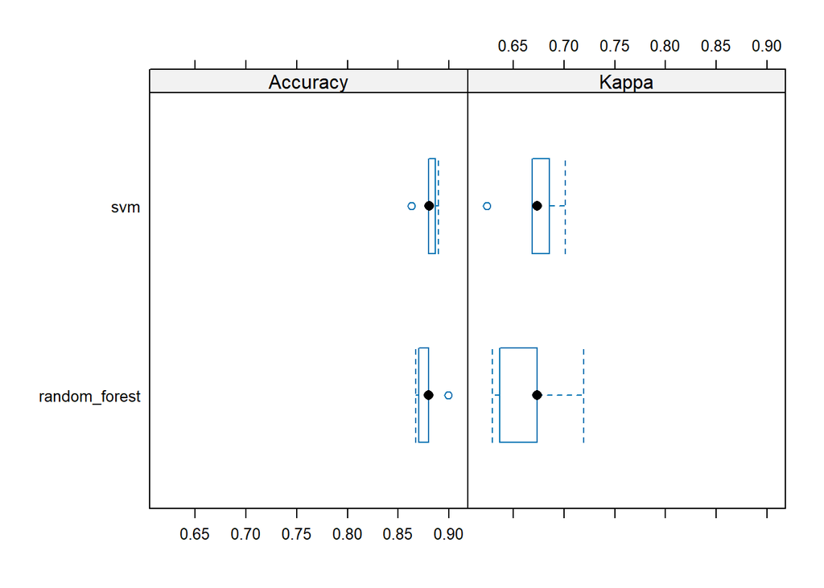

```r
bwplot(results)
```

Interpretation: Hyperparameter tuning for Random Forest and Support Vector Machine (SVM) models is conducted using grid search and cross-validation. The Random Forest model, tuned for mtry, achieves an accuracy of 85.97% with a Kappa of 0.603. The SVM model, tuned for sigma and C, attains an accuracy of 86.23% with a Kappa of 0.622. Both models exhibit similar performance, with the SVM slightly outperforming in balanced accuracy. The resampling summary confirms these results, showing the mean accuracy and Kappa values are comparable for both models, indicating robust model performance across different hyperparameters.

Evaluate it based on a variety of metrics as well as analysing it’s performance (does it overtrain, can we improve it by changing our data preprocessing etc.)

```r
# Analyze overfitting
# Check performance on training data
train_predictions_rf <- predict(model_rf, newdata = trainData_selected)
train_predictions_rf <- factor(train_predictions_rf, levels = levels(trainData_selected$ICU))
confusionMatrix(train_predictions_rf, trainData_selected$ICU)
```

```
## Confusion Matrix and Statistics
##
##           Reference
## Prediction    0    1
##          0 1128   44
##          1    0  368
##
##                Accuracy : 0.9714
##                  95% CI : (0.9618, 0.9792)
##     No Information Rate : 0.7325
##     P-Value [Acc > NIR] : < 2.2e-16
##
##                   Kappa : 0.9245
##
##  Mcnemar's Test P-Value : 9.022e-11
##
##             Sensitivity : 1.0000
##             Specificity : 0.8932
##          Pos Pred Value : 0.9625
##          Neg Pred Value : 1.0000
##              Prevalence : 0.7325
##          Detection Rate : 0.7325
##    Detection Prevalence : 0.7610
##       Balanced Accuracy : 0.9466
##
##        'Positive' Class : 0
##
```

```r
# Check performance on test data
test_predictions_rf <- predict(model_rf, newdata = testData_selected)
test_predictions_rf <- factor(test_predictions_rf, levels = levels(testData_selected$ICU))
confusionMatrix(test_predictions_rf, testData_selected$ICU)
```

```
## Confusion Matrix and Statistics
##
##           Reference
## Prediction   0   1
##          0 271  43
##          1  11  60
##
##                Accuracy : 0.8597
##                  95% CI : (0.821, 0.8928)
##     No Information Rate : 0.7325
##     P-Value [Acc > NIR] : 1.351e-09
##
##                   Kappa : 0.603
##
##  Mcnemar's Test P-Value : 2.459e-05
##
##             Sensitivity : 0.9610
##             Specificity : 0.5825
##          Pos Pred Value : 0.8631
##          Neg Pred Value : 0.8451
##              Prevalence : 0.7325
##          Detection Rate : 0.7039
##    Detection Prevalence : 0.8156
##       Balanced Accuracy : 0.7718
##
##        'Positive' Class : 0
##
```

Interpretation: The Random Forest model exhibits a high accuracy of 97.14% on the training data, with a Kappa of 0.9245, indicating excellent agreement. However, on the test data, the accuracy drops to 85.97% with a Kappa of 0.603, suggesting moderate agreement. The significant performance difference between training and test sets indicates overfitting, where the model performs exceptionally well on the training data but struggles to generalize to unseen test data. This discrepancy is further highlighted by the high sensitivity (1.000) on the training set compared to the lower sensitivity (0.961) and specificity (0.5825) on the test set.